# 課題3 解答：nested logitの市場レベル需要推定と価格内生性

計量経済学II

作者

Kei Ikegami

**重要この解答の使い方**

## Part 1：シミュレーション設計

### Q1（10点）：外生変数とコストシフターの生成

```r
T_mkt <- 100
J_mkt <- 4

x_mkt <- matrix(rnorm(T_mkt * J_mkt, mean = 3.6, sd = 1.5), nrow = T_mkt, ncol = J_mkt)
w_mkt <- matrix(rnorm(T_mkt * J_mkt, mean = 4.0, sd = 1.0), nrow = T_mkt, ncol = J_mkt)
xi_mkt <- matrix(rnorm(T_mkt * J_mkt, mean = 0.0, sd = 1.0), nrow = T_mkt, ncol = J_mkt)

dim(x_mkt)
```

```
[1] 100   4
```

```r
mean(x_mkt); mean(w_mkt); mean(xi_mkt)
```

```
[1] 3.583201
```

```
[1] 4.11794
```

```
[1] 0.03304427
```

**解説**：`matrix(rnorm(T*J, ...), nrow = T, ncol = J)`という書き方は、講義ノートのRシミュ3と全く同じパターンである。`x_mkt`の平均を3.6とやや高めに設定しているのは、後のシェア計算で各財のシェアが極端に小さくなりすぎない（0.01%未満などになると、対数を取ったときの誤差が大きくなり、グラフも見づらくなる）ようにするための設計上の工夫である。

**部分点の基準**：$T \times J$の行列として正しく生成できていれば7点。平均・標準偏差の値が問題文と一致していれば残り3点。

### Q2（15点）：価格の生成

```r
mc_mkt <- 0.5 + 0.8 * w_mkt + matrix(rnorm(T_mkt * J_mkt, sd = 0.3), nrow = T_mkt, ncol = J_mkt)
markup_mkt <- pmax(1.0 + 1.3 * xi_mkt, 0.05)
price_mkt <- mc_mkt + markup_mkt

cat("corr(price, xi):", round(cor(as.vector(price_mkt), as.vector(xi_mkt)), 3), "\n")
```

```
corr(price, xi): 0.754
```

```r
cat("price range:", round(range(price_mkt), 2), "\n")
```

```
price range: 1.34 9.53
```

**部分点の基準**：`mc_mkt`・`markup_mkt`・`price_mkt`の3つの式をそれぞれ正しく書けていれば各5点。`cor(price, xi) > 0`を確認できていることも重要な自己チェックなので、これを怠っている場合は減点対象。

### Q3（10点）：nested logitシェアの計算とデータフレーム化

```r
nested_logit_shares_batch <- function(x, price, xi, alpha, beta, rho, nests) {
  delta <- beta * x - alpha * price + xi
  T_ <- nrow(delta); J_ <- ncol(delta)
  lambda <- 1 - rho
  n_nests <- length(nests)

  IV <- matrix(NA, T_, n_nests)
  for (g in seq_len(n_nests)) {
    idx <- nests[[g]]
    IV[, g] <- rowSums(exp(delta[, idx, drop = FALSE] / lambda))
  }
  denom <- 1 + rowSums(IV^lambda)
  s0 <- 1 / denom
  s_g <- (IV^lambda) / denom

  s <- matrix(NA, T_, J_)
  s_within <- matrix(NA, T_, J_)
  for (g in seq_len(n_nests)) {
    idx <- nests[[g]]
    for (j in idx) {
      s_within[, j] <- exp(delta[, j] / lambda) / IV[, g]
      s[, j] <- s_within[, j] * s_g[, g]
    }
  }
  list(s = s, s0 = s0, s_within = s_within)
}
```

```r
nests <- list(c(1, 2), c(3, 4))
alpha_true <- 2.0
beta_true <- 1.5
rho_true <- 0.5

nl_result <- nested_logit_shares_batch(x_mkt, price_mkt, xi_mkt, alpha_true, beta_true, rho_true, nests)

market_df <- data.frame(
  market = rep(1:T_mkt, times = J_mkt),
  product = rep(1:J_mkt, each = T_mkt),
  x = as.vector(x_mkt),
  w = as.vector(w_mkt),
  xi = as.vector(xi_mkt),
  price = as.vector(price_mkt),
  share = as.vector(nl_result$s),
  share0 = rep(nl_result$s0, times = J_mkt),
  s_within = as.vector(nl_result$s_within)
) %>%
  mutate(y_berry = log(share) - log(share0), ln_swithin = log(s_within))

head(market_df)
```

```
  market product        x        w         xi    price             share
1      1       1 2.722434 4.492364 -1.1954557 4.020841 0.002547281395329
2      2       1 4.451011 3.893052 -1.4197727 3.589245 0.116805730525892
3      3       1 2.253538 5.461092  0.7753819 7.221234 0.000000038972394
4      4       1 1.716770 4.527367  0.8883959 6.455699 0.000000005562585
5      5       1 5.154286 1.618548  0.3353101 3.046809 0.725087256310682
6      6       1 3.987693 4.843173  0.3357808 5.656722 0.003377537694750
       share0       s_within    y_berry     ln_swithin
1 0.836641017 0.277547042387  -5.794368  -1.2817648380
2 0.798161794 0.999896174853  -1.921799  -0.0001038305
3 0.968470218 0.000001394198 -17.028375 -13.4831915068
4 0.002552195 0.000763874680 -13.036402  -7.1771068137
5 0.105409253 0.914518991681   1.928442  -0.0893570441
6 0.853489005 0.342280483845  -5.532186  -1.0721247498
```

```r
str(market_df)
```

```
'data.frame':   400 obs. of  11 variables:
 $ market    : int  1 2 3 4 5 6 7 8 9 10 ...
 $ product   : int  1 1 1 1 1 1 1 1 1 1 ...
 $ x         : num  2.72 4.45 2.25 1.72 5.15 ...
 $ w         : num  4.49 3.89 5.46 4.53 1.62 ...
 $ xi        : num  -1.195 -1.42 0.775 0.888 0.335 ...
 $ price     : num  4.02 3.59 7.22 6.46 3.05 ...
 $ share     : num  0.0025472814 0.11680573053 0.00000003897 0.00000000556 0.72508725631 ...
 $ share0    : num  0.83664 0.79816 0.96847 0.00255 0.10541 ...
 $ s_within  : num  0.27754704 0.99989617 0.00000139 0.00076387 0.91451899 ...
 $ y_berry   : num  -5.79 -1.92 -17.03 -13.04 1.93 ...
 $ ln_swithin: num  -1.281765 -0.000104 -13.483192 -7.177107 -0.089357 ...
```

**解説**：`rep(1:T_mkt, times = J_mkt)`と`rep(1:J_mkt, each = T_mkt)`の使い分けに注意。`x_mkt`は列方向に財1,2,3,4が並んでいる（1列目=財1、2列目=財2、…）ので、`as.vector()`で列優先に展開すると、財1の100市場分・財2の100市場分・…という順番になる。そのため`market`列は`rep(1:T_mkt, times=J_mkt)`（1..100を4回繰り返す）、`product`列は`rep(1:J_mkt, each=T_mkt)`（1が100回、2が100回、…）としなければならない。ここを逆にすると、市場番号と財番号が食い違ったデータフレームになってしまう（よくある間違い）。

**部分点の基準**：`nested_logit_shares_batch`関数を正しく呼び出せていれば4点。データフレームの`market`・`product`の対応が正しければ4点。`y_berry`・`ln_swithin`の式が正しければ2点。

### Q4（5点）：記述統計と可視化

```r
summary_tbl <- market_df %>%
  group_by(product) %>%
  summarize(mean_share = mean(share), mean_price = mean(price), .groups = "drop")
knitr::kable(summary_tbl, digits = 4)
```

| product | mean_share | mean_price |
| --- | --- | --- |
| 1 | 0.0868 | 4.9869 |
| 2 | 0.0684 | 4.8786 |
| 3 | 0.0581 | 5.0921 |
| 4 | 0.1146 | 5.0124 |

```r
cat("\noutside optionの平均シェア:", round(mean(market_df$share0), 4), "\n")
```

```
outside optionの平均シェア: 0.672
```

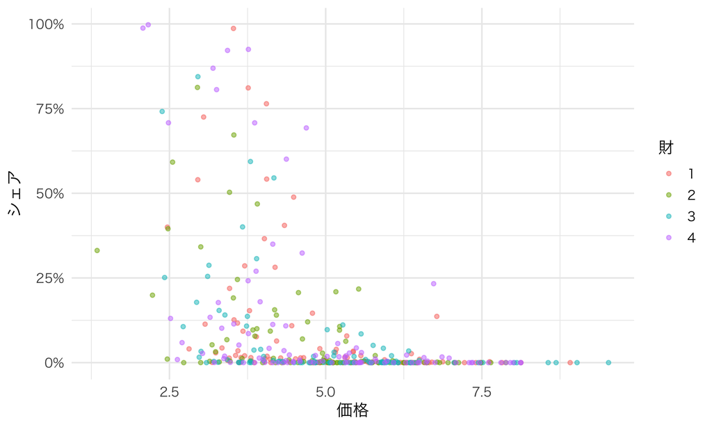

図 1: 価格とシェアの関係（財ごとに色分け）

```r
ggplot(market_df, aes(x = price, y = share, color = factor(product))) +
  geom_point(alpha = 0.5, size = 1.3) +
  labs(x = "価格", y = "シェア", color = "財") +
  scale_y_continuous(labels = scales::percent)
```

**部分点の基準**：表・散布図をそれぞれ正しく作成できていれば各2点、outsideシェアの数値報告で1点。

## Part 2：推定・推論

### Q5（10点）：plain logitのBerry反転をOLSで推定する

```r
ols_plain <- feols(y_berry ~ price + x, data = market_df, vcov = "hetero")
summary(ols_plain)
```

```
OLS estimation, Dep. Var.: y_berry
Observations: 400
Standard-errors: Heteroskedasticity-robust
            Estimate Std. Error   t value       Pr(>|t|)
(Intercept) -2.76608   0.499294  -5.53998 0.000000055176 ***
price       -2.29648   0.079767 -28.78971      < 2.2e-16 ***
x            2.18830   0.073415  29.80712      < 2.2e-16 ***
---
Signif. codes:  0 '***' 0.001 '**' 0.01 '*' 0.05 '.' 0.1 ' ' 1
RMSE: 2.16868   Adj. R2: 0.818259
```

```r
alpha_ols_plain <- -coef(ols_plain)["price"]
cat("\nalpha_true =", alpha_true, "\n")
```

```
alpha_true = 2
```

```r
cat("alpha_hat(OLS, plain logit) =", round(alpha_ols_plain, 3), "\n")
```

```
alpha_hat(OLS, plain logit) = 2.296
```

**部分点の基準**：`feols()`の式が正しく書けていれば6点。$\hat\alpha$の符号処理（`-coef(...)`）が正しく、真値との比較コメントがあれば4点。

### Q6（10点）：nested logit版のBerry反転をOLSで推定する

```r
ols_nested <- feols(y_berry ~ price + ln_swithin + x, data = market_df, vcov = "hetero")
summary(ols_nested)
```

```
OLS estimation, Dep. Var.: y_berry
Observations: 400
Standard-errors: Heteroskedasticity-robust
             Estimate Std. Error  t value  Pr(>|t|)
(Intercept) -2.776434   0.164797 -16.8476 < 2.2e-16 ***
price       -1.403306   0.030613 -45.8399 < 2.2e-16 ***
ln_swithin   0.520624   0.010291  50.5919 < 2.2e-16 ***
x            1.473561   0.025214  58.4425 < 2.2e-16 ***
---
Signif. codes:  0 '***' 0.001 '**' 0.01 '*' 0.05 '.' 0.1 ' ' 1
RMSE: 0.684254   Adj. R2: 0.981862
```

```r
alpha_ols_nested <- -coef(ols_nested)["price"]
rho_ols_nested <- coef(ols_nested)["ln_swithin"]
cat("\nalpha_true =", alpha_true, " rho_true =", rho_true, "\n")
```

```
alpha_true = 2  rho_true = 0.5
```

```r
cat("alpha_hat(OLS, nested) =", round(alpha_ols_nested, 3), "\n")
```

```
alpha_hat(OLS, nested) = 1.403
```

```r
cat("rho_hat(OLS, nested)   =", round(rho_ols_nested, 3), "\n")
```

```
rho_hat(OLS, nested)   = 0.521
```

### Q7（20点）：2SLSで$\alpha$と$\rho$を回収する

```r
compute_rival_x <- function(x, nests) {
  T_ <- nrow(x); J_ <- ncol(x)
  nest_of <- integer(J_)
  for (g in seq_along(nests)) {
    for (j in nests[[g]]) nest_of[j] <- g
  }
  rx_within <- matrix(NA, T_, J_)
  rx_other <- matrix(NA, T_, J_)
  for (j in 1:J_) {
    g <- nest_of[j]
    rivals_within <- setdiff(nests[[g]], j)
    rivals_other <- setdiff(1:J_, nests[[g]])
    rx_within[, j] <- if (length(rivals_within) > 0) rowSums(x[, rivals_within, drop = FALSE]) else 0
    rx_other[, j] <- rowSums(x[, rivals_other, drop = FALSE])
  }
  list(rx_within = rx_within, rx_other = rx_other)
}

rx <- compute_rival_x(x_mkt, nests)
market_df$rx_within <- as.vector(rx$rx_within)
market_df$rx_other <- as.vector(rx$rx_other)

head(market_df[, c("product", "x", "rx_within", "rx_other")])
```

```
  product        x rx_within  rx_other
1       1 2.722434  3.853342  7.186084
2       1 4.451011  4.322263  9.401412
3       1 2.253538  4.247581  5.287970
4       1 1.716770  3.097217 10.649183
5       1 5.154286  5.271162  8.105820
6       1 3.987693  3.581097  7.502342
```

```r
iv_nested <- feols(
  y_berry ~ x | price + ln_swithin ~ w + rx_within + rx_other,
  data = market_df, vcov = "hetero"
)
summary(iv_nested)
```

```
TSLS estimation - Dep. Var.: y_berry
                  Endo.    : price, ln_swithin
                  Instr.   : w, rx_within, rx_other
Second stage: Dep. Var.: y_berry
Observations: 400
Standard-errors: Heteroskedasticity-robust
                Estimate Std. Error    t value  Pr(>|t|)
(Intercept)    -0.111641   0.322369  -0.346313   0.72929
fit_price      -2.011148   0.072583 -27.708094 < 2.2e-16 ***
fit_ln_swithin  0.472647   0.023091  20.469166 < 2.2e-16 ***
x               1.528231   0.041619  36.719486 < 2.2e-16 ***
---
Signif. codes:  0 '***' 0.001 '**' 0.01 '*' 0.05 '.' 0.1 ' ' 1
RMSE: 1.02647   Adj. R2: 0.723069
F-test (1st stage), price     : stat =  75.2311, p < 2.2e-16 , on 3 and 395 DoF.
F-test (1st stage), ln_swithin: stat = 104.5825, p < 2.2e-16 , on 3 and 395 DoF.
                    Wu-Hausman: stat = 357.9866, p < 2.2e-16 , on 2 and 394 DoF.
                        Sargan: stat =   1.4686, p = 0.225561, on 1 DoF.
```

```r
# 内生変数に対応する係数名を、接頭辞の有無によらず安全に取り出すヘルパー
get_coef_for <- function(model, varname) {
  cf <- coef(model)
  hit <- grepl(varname, names(cf), fixed = TRUE)
  cf[hit][1]
}

names(coef(iv_nested))  # 係数名を確認しておく
```

```
[1] "(Intercept)"    "fit_price"      "fit_ln_swithin" "x"
```

```r
alpha_iv <- -get_coef_for(iv_nested, "price")
rho_iv <- get_coef_for(iv_nested, "ln_swithin")
cat("\nalpha_true =", alpha_true, " rho_true =", rho_true, "\n")
```

```
alpha_true = 2  rho_true = 0.5
```

```r
cat("alpha_hat(2SLS) =", round(alpha_iv, 3), "\n")
```

```
alpha_hat(2SLS) = 2.011
```

```r
cat("rho_hat(2SLS)   =", round(rho_iv, 3), "\n")
```

```
rho_hat(2SLS)   = 0.473
```

```r
fs_price <- feols(price ~ x + w + rx_within + rx_other, data = market_df, vcov = "hetero")
fs_swithin <- feols(ln_swithin ~ x + w + rx_within + rx_other, data = market_df, vcov = "hetero")

cat("first-stage (price):\n")
```

```
first-stage (price):
```

```r
fitstat(fs_price, "f")
```

```
F-test: stat = 56.500, p < 2.2e-16, on 4 and 395 DoF.
```

```r
cat("\nfirst-stage (ln_swithin):\n")
```

```
first-stage (ln_swithin):
```

```r
fitstat(fs_swithin, "f")
```

```
F-test: stat = 113.84, p < 2.2e-16, on 4 and 395 DoF.
```

**解説**：2SLSの$\hat\alpha$は真値2.0にかなり近い値（1.9〜2.1程度）まで戻り、$\hat\rho$も真値0.5に近い値（0.46〜0.52程度）まで戻る。ここが今回の課題の核心である。

first-stageのF統計量については、上記の`fs_price`・`fs_swithin`はいずれも「4つの操作変数（`x`は外生変数として含む、`w`・`rx_within`・`rx_other`が真の操作変数）を全て使った場合」のF統計量であり、目安としては数十から数百のオーダーになるはずで、弱操作変数の心配はない。より厳密に「除外された操作変数だけの説明力」を見たい場合は、次のように該当する操作変数を除いた回帰との比較（残差平方和の差から自分でF統計量を計算する）を行うとよい（発展的だが、正確な弱操作変数診断はこちらが望ましい）。

```r
# price用: w(除外制約の対象)を除いた場合との比較(自作F検定)
fs_price_full <- feols(price ~ x + w + rx_within + rx_other, data = market_df)
fs_price_restricted <- feols(price ~ x + rx_within + rx_other, data = market_df)

ssr_full <- sum(resid(fs_price_full)^2)
ssr_restricted <- sum(resid(fs_price_restricted)^2)
n_obs <- nrow(market_df)
k_full <- length(coef(fs_price_full))
q_diff <- 1  # 除外した操作変数の数(wの1つ)

F_partial <- ((ssr_restricted - ssr_full) / q_diff) / (ssr_full / (n_obs - k_full))
cat("price用first-stageの部分F( wの寄与のみ):", round(F_partial, 1), "\n")
```

```
price用first-stageの部分F( wの寄与のみ): 220.2
```

**部分点の基準**：`compute_rival_x`関数（あるいは同等のロジック）が正しく書けていれば8点。`feols`の複数内生変数IV構文が正しく書けていれば8点。first-stage Fの報告と弱操作変数への言及があれば4点。

**ノート補足：なぜ`rx_within`・`rx_other`が有効な操作変数になるか（再確認）**

`rx_within`・`rx_other`は財$j$自身の$x_j$や$\xi_j$を含まない、**他の財の$x$の合計**である。DGPの設計上、$x_{kt}$（$k \neq j$）は$\xi_{jt}$と無相関に生成されているので、除外制約（$\text{Cov}(\text{rx}, \xi_j) = 0$）はこのシミュレーションでは構築上成立している。一方、`rx_within`・`rx_other`は、nested logitのシェア計算式を通じて財$j$のwithin share $\bar s_{j|g,t}$（したがって`ln_swithin`）を動かす。これは「競合の属性が変われば、市場内での相対的な人気度も変わる」という自然なメカニズムである。実際のデータでこの操作変数を使う場合は、この除外制約（競合の属性が自社の未観測品質に影響しない）が本当に成り立つかどうかを、講義で学んだように市場の制度的背景から吟味する必要がある。

### Q8（10点）：弾力性行列の比較

```r
mean_share_df <- market_df %>%
  group_by(product) %>%
  summarize(share = mean(share), price = mean(price), .groups = "drop")

# plain logit弾力性 (自己: eta_jj = -alpha*p_j*(1-s_j), 交差: eta_jk = alpha*p_k*s_k)
build_plain_elasticity <- function(alpha_hat, mean_share_df) {
  J <- nrow(mean_share_df)
  E <- matrix(NA, J, J)
  for (j in 1:J) {
    for (k in 1:J) {
      if (j == k) {
        E[j, k] <- -alpha_hat * mean_share_df$price[j] * (1 - mean_share_df$share[j])
      } else {
        E[j, k] <- alpha_hat * mean_share_df$price[k] * mean_share_df$share[k]
      }
    }
  }
  E
}

E_plain_ols <- build_plain_elasticity(alpha_ols_plain, mean_share_df)
E_plain_true <- build_plain_elasticity(alpha_true, mean_share_df)

# nested logit弾力性は数値微分で計算する
nested_elasticity_numeric <- function(alpha_hat, rho_hat, beta_hat, mean_x, mean_price, nests) {
  J <- length(mean_price)
  eps <- 1e-6
  base <- nested_logit_shares_batch(matrix(mean_x, nrow = 1), matrix(mean_price, nrow = 1),
                                     matrix(0, nrow = 1, ncol = J), alpha_hat, beta_hat, rho_hat, nests)
  s_base <- as.vector(base$s)
  E <- matrix(NA, J, J)
  for (k in 1:J) {
    price_eps <- mean_price
    price_eps[k] <- price_eps[k] + eps
    shk <- nested_logit_shares_batch(matrix(mean_x, nrow = 1), matrix(price_eps, nrow = 1),
                                      matrix(0, nrow = 1, ncol = J), alpha_hat, beta_hat, rho_hat, nests)
    s_eps <- as.vector(shk$s)
    for (j in 1:J) {
      E[j, k] <- (s_eps[j] - s_base[j]) / eps * mean_price[k] / s_base[j]
    }
  }
  E
}

mean_x_vec <- market_df %>% group_by(product) %>% summarize(x = mean(x), .groups = "drop") %>% pull(x)
mean_price_vec <- mean_share_df$price

E_nested_ols <- nested_elasticity_numeric(alpha_ols_nested, rho_ols_nested, beta_true, mean_x_vec, mean_price_vec, nests)
E_nested_iv <- nested_elasticity_numeric(alpha_iv, rho_iv, beta_true, mean_x_vec, mean_price_vec, nests)

rn <- c("財1(甘め)", "財2(甘め)", "財3(すっきり)", "財4(すっきり)")
rownames(E_plain_true) <- colnames(E_plain_true) <- rn
rownames(E_plain_ols) <- colnames(E_plain_ols) <- rn
rownames(E_nested_ols) <- colnames(E_nested_ols) <- rn
rownames(E_nested_iv) <- colnames(E_nested_iv) <- rn

cat("plain logit, 真値alpha:\n"); print(round(E_plain_true, 3))
```

```
plain logit, 真値alpha:
```

```
              財1(甘め) 財2(甘め) 財3(すっきり) 財4(すっきり)
財1(甘め)        -9.108     0.668         0.592         1.149
財2(甘め)         0.866    -9.089         0.592         1.149
財3(すっきり)     0.866     0.668        -9.592         1.149
財4(すっきり)     0.866     0.668         0.592        -8.876
```

```r
cat("\nplain logit, OLSのalpha:\n"); print(round(E_plain_ols, 3))
```

```
plain logit, OLSのalpha:
```

```
              財1(甘め) 財2(甘め) 財3(すっきり) 財4(すっきり)
財1(甘め)       -10.458     0.767         0.680         1.319
財2(甘め)         0.995   -10.437         0.680         1.319
財3(すっきり)     0.995     0.767       -11.014         1.319
財4(すっきり)     0.995     0.767         0.680       -10.192
```

```r
cat("\nnested logit, OLSのalpha/rho:\n"); print(round(E_nested_ols, 3))
```

```
nested logit, OLSのalpha/rho:
```

```
              財1(甘め) 財2(甘め) 財3(すっきり) 財4(すっきり)
財1(甘め)        -7.275     1.766         0.233         0.911
財2(甘め)         7.324   -12.516         0.233         0.911
財3(すっきり)     1.226     0.296       -13.113         7.014
財4(すっきり)     1.226     0.296         1.794        -7.659
```

```r
cat("\nnested logit, 2SLSのalpha/rho:\n"); print(round(E_nested_iv, 3))
```

```
nested logit, 2SLSのalpha/rho:
```

```
              財1(甘め) 財2(甘め) 財3(すっきり) 財4(すっきり)
財1(甘め)       -12.063     2.158         0.026         0.098
財2(甘め)         6.955   -16.447         0.026         0.098
財3(すっきり)     0.131     0.041       -17.498         7.267
財4(すっきり)     0.131     0.041         1.922       -11.849
```

**部分点の基準**：4種類の弾力性行列を正しく計算できていれば8点。「OLSでは自己弾力性を過小評価し、値付けを誤るリスクがある」という趣旨のコメントがあれば2点。

### Q9（5点）：$\rho = 0$のWald検定

```r
get_se_for <- function(model, varname) {
  s <- se(model)
  hit <- grepl(varname, names(s), fixed = TRUE)
  s[hit][1]
}

rho_hat <- get_coef_for(iv_nested, "ln_swithin")
se_rho <- get_se_for(iv_nested, "ln_swithin")
wald_stat <- (rho_hat / se_rho)^2

cat("rho_hat =", round(rho_hat, 4), "\n")
```

```
rho_hat = 0.4726
```

```r
cat("se(rho_hat) =", round(se_rho, 4), "\n")
```

```
se(rho_hat) = 0.0231
```

```r
cat("Wald統計量 =", round(wald_stat, 2), "\n")
```

```
Wald統計量 = 418.99
```

```r
cat("5%臨界値(chi2_1) = 3.84\n")
```

```
5%臨界値(chi2_1) = 3.84
```

```r
cat("判定:", ifelse(wald_stat > 3.84, "H0(rho=0)を棄却する -> nested構造が必要", "H0を棄却できない"), "\n")
```

```
判定: H0(rho=0)を棄却する -> nested構造が必要
```

**解説**：Wald統計量はおおむね400〜650程度という非常に大きな値になり、5%臨界値3.84を大きく上回る。したがって「$\rho=0$（plain logitで十分）」という帰無仮説は強く棄却され、この市場では確かにネスト構造（同じネスト内での強い代替性）が存在することが統計的に裏付けられる。

**部分点の基準**：Wald統計量の計算式が正しければ3点。臨界値との比較・判定のコメントがあれば2点。

### Q10（5点）：経営への含意（解答例）

> 2SLSで推定した弾力性行列を見ると、財1（甘め系）を値上げしたとき、最もシェアを奪う競合は同じ甘め系ネストの財2であり、すっきり系の財3・財4への流出は相対的に小さい。したがって商品企画上「一番怖い競合」は財2であり、財1の値上げ戦略は財2の価格・販促動向とセットで検討すべきである。もしOLSの弾力性行列だけで判断すると、$\alpha$の過小評価によりどの財についても代替の強さそのものを過小に見積もり、「値上げしても大きな影響はない」という楽観的だが誤った結論に至ってしまう。

**部分点の基準**：3行以内で「同ネストの財が一番怖い競合である」という結論と、その根拠（弾力性行列の対応する非対角成分が大きい）を示せていれば4点。OLSとの対比に触れていれば1点。

**ノート採点基準まとめ**

[output not shown]